# Bayesian forecast fan charts

Andrew P Blake

October 2020

> *The Bank of England does not accept any liability for misleading or inaccurate information or omissions in the information provided. The subject matter reflects the views of the individual presenter and not the wider Bank of England or its Policy Committees.*

## A Bayesian fan chart

- We can justify the Bayesian approach because we are able to quantify uncertainty completely
  - Not just from the data but judgment is used in an explicit way
- To do this we generate sequences from which we calculate statistics of interest
- Can we use this for a forecast?
- Once the Gibbs sampler has converged we have a set of valid draws that characterize the model
- We can forecast using every draw of this model and then calculate the density of the forecast from the resulting sequences of forecasts
- These are *posterior sub draws*

## Forecasting inflation

- Consider the recursive forecast generated from the $AR(2)$ model
  $$\begin{align}
  \pi_{t+1}^j &= c^j + B_1^j \pi_t + B_2^j \pi_{t-1} + \varepsilon_{t+1}^j \\
  \pi_{t+2}^j &= c^j + B_1^j \pi_{t+1}^j + B_2^j \pi_t + \varepsilon_{t+2}^j \\
  &\qquad\qquad \vdots \\
  \pi_{t+q}^j &= c^j + B_1^j \pi_{t+p-1}^j + B_2^j \pi_{t+p-2}^j + \varepsilon_{t+p-2}^j
  \end{align}$$
  for some horizon $q$
- Store the complete series of values for $\pi_{t+1}^j$ to $\pi_{t+p}^j$
- This gives us an empirical distribution for the forecast that encapsulates the uncertainty associated with all of the parameters and the future unknown shocks
- We can plot a density and hence a fan chart of this easily

## US CPI inflation example

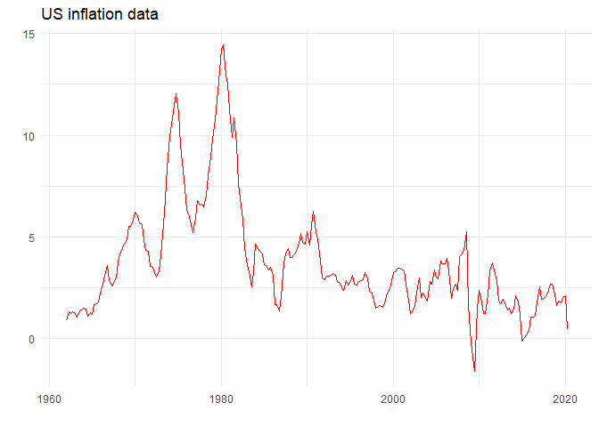

```r
library(tidyverse)
library(kableExtra)

max_lag <- 4
series  <- "CPALTT01USQ661S"
url     <- paste0("https://fred.stlouisfed.org/series/", series, "/downloaddata/",series,".csv")

download.file(url, "CPI.csv")
data <- readr::read_csv("CPI.csv")  %>%
  rename(Date=DATE, value=VALUE) %>%
  mutate(Vars = "INF",
         Vals = 100*(value/lag(value,4)-1),
         lagi = list(0:max_lag)) %>%
  slice(-c(1:4)) %>%
  unnest(cols = c(lagi)) %>%
  group_by(lagi) %>%
  mutate(Vals = lag(Vals, lagi[1])) %>%
  ungroup() %>%
  mutate(Varl = paste(Vars, lagi, sep="_"),
         Vars = if_else(lagi==0, Vars, Varl)) %>%
  select(Date,Vars,Vals) %>%
  pivot_wider(names_from = Vars, values_from = Vals) %>%
  slice(-c(1:max_lag)) %>%
  mutate(constant = 1)

ggplot(data) +
  geom_line(aes(x=Date, y=INF), colour="red") +
  theme_minimal() +
  labs(title="US inflation data", x="", y="")
```

```r
X <- data %>%
  select(-Date, -INF) %>%
  data.matrix(.)
Y <- data %>%
  select(INF) %>%
  data.matrix(.)
T <- nrow(Y)

# Save for later use
XX      <- crossprod(X)
XY      <- crossprod(X,Y)
iXX     <- chol2inv(chol(XX))

# Periods to forecast/plot
nf <- 12
nb <- 16

# step 1 set priors and starting values
# priors for B
B0     <- matrix(0,max_lag+1,1)
Sigma0 <- diag(max_lag+1)
# priors for sigma2
T0     <- 1L
D0     <- 0.1

# starting values
B      <- B0
sigma2 <- 1

# Store further numbers for repeated use
iS0   <- chol2inv(chol(Sigma0))
T1    <- T0 + T
YL    <- tail(Y,4)[max_lag:1]
const <- matrix(0,max_lag,1)
BB    <- matrix(0,max_lag,1)

# Store Gibbs samples
reps <- 20000   # total numbers of Gibbs iterations
burn <- 10000   # number of burn-in iterations
out  <- matrix(0,reps-burn,max_lag+2)
outf <- matrix(0,reps-burn,nf)

for (i in 1:reps) {

  V <- XX/sigma2[1] + iS0
  M <- solve(V, XY/sigma2[1] + iS0%*%B0)

  eigs <- 2
  while(max(abs(eigs)) > 1) {
    b    <- M + crossprod(chol2inv(chol(V)),rnorm(max_lag+1))
    A    <- rbind(t(b[-length(b)]), diag(1,max_lag-1,max_lag))
    eigs <- eigen(A, symmetric=FALSE, only.values=TRUE)$values
    }

  # sample sigma2 conditional on b from IG(T1,D1);
  err    <- Y - X%*%b
  # compute posterior df and scale matrix
  D1     <- D0 + crossprod(err)
  # draw from IG
  z0     <- rnorm(T1)
  sigma2 <- D1/crossprod(z0)

  if (i > burn) {
    out[i-burn,] <- c(t(b), sigma2)
    const[1]     <- b[length(b)]
    Yf           <- YL
    for (j in 1:nf) {
      BB[1]          <- sqrt(sigma2)*rnorm(1)
      Yf             <- const + A%*%Yf + BB
      outf[i-burn,j] <- Yf[1]
      }
    }
  }

# Fancharts
# Calculate bands
fdt <- seq.Date(tail(data$Date,1), by="quarter", length.out=nf+1)
qm  <-   apply(outf, 2, quantile, probs=c(.5))
mm  <- t(apply(outf, 2, quantile, probs=c(.05,.20,.35,.65,.80,.95))) %>%
  rbind(rep(tail(Y,1),6), .)

pg  <- rbind(mm[,-6], mm[(nf+1):1,-1]) %>%
  as_tibble() %>%
  rename_all( ~ c(paste0("Area",1:5))) %>%
  mutate(Date = c(fdt,rev(fdt))) %>%
  gather(Area, coord, -Date)

bd  <- bind_rows(tibble(Date=tail(data$Date,nb), Data=tail(Y,nb)),
                 tibble(Date=fdt[-1],      Data=qm))

col_tail <- "grey95"
centre   <- c("tomato","maroon4","royalblue4","peru","seagreen")
j        <- 1
col      <- colorRampPalette(c(col_tail,centre[j],col_tail))(7)

# Rearrange output
fdens <- outf %>%
  as_tibble(.name_repair = "unique") %>%
  rename_all(~ c(paste0("pi[T+",formatC(1:nf, width=2, flag="0"),"]"))) %>%
  mutate(iter = 1:(reps-burn)) %>%
  pivot_longer(cols = -iter, names_to = "par", values_to = "val")
```

### Sub draws

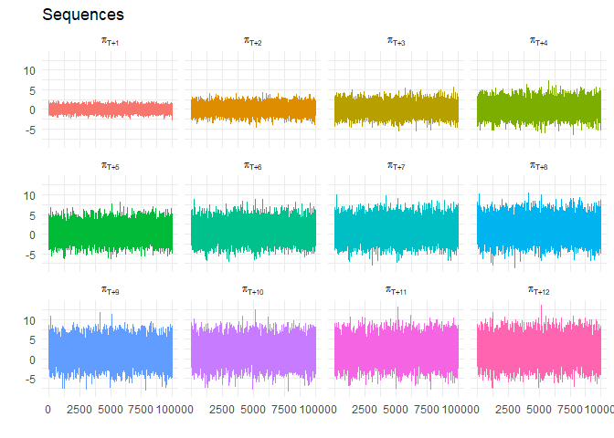

```r
# Plot sequences
fsdens <- ggplot(fdens) +
  geom_line(aes(x=iter, y=val, group=par, colour=par), show.legend=FALSE) +
  facet_wrap(~par, labeller=label_parsed, ncol=4) +
  theme_minimal() +
  labs(title="Sequences", x="", y="")
plot(fsdens)
```

#### Sequence of sub draws at each forecast horizon

### Densities

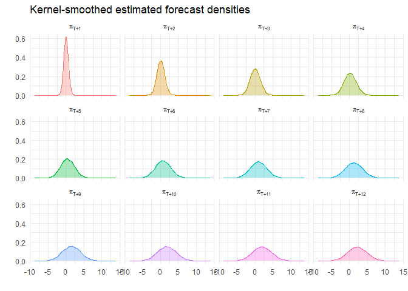

```r
# Plot estimated densities
fpdens <- ggplot(fdens) +
  geom_histogram(aes(x=val, y=..density.., group=par, fill=par), alpha=0.33, bins=50) +
  geom_density(aes(val, group=par, colour=par)) +
  # geom_density(aes(val, group=par, colour=par, fill=par), alpha = .1) +
  facet_wrap(~par, labeller=label_parsed, ncol=4) +
  theme_minimal() +
  theme(legend.position = "none") +
  labs(title="Kernel-smoothed estimated forecast densities", x="", y="")
plot(fpdens)
```

#### Histograms and kernel-smoothed estimates from each

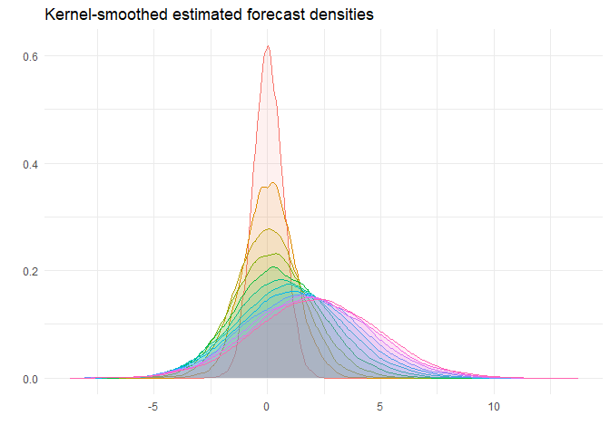

```r
# Plot estimated densities
fpdens <- ggplot(fdens) +
  # geom_histogram(aes(x=val, y=..density.., group=par, fill=par), alpha=0.33, bins=50) +
  # geom_density(aes(val, group=par, colour=par)) +
  geom_density(aes(val, group=par, colour=par, fill=par), alpha = .1) +
  # facet_wrap(~par, labeller=label_parsed, ncol=4) +
  theme_minimal() +
  theme(legend.position = "none") +
  labs(title="Kernel-smoothed estimated forecast densities", x="", y="")
plot(fpdens)
```

#### All estimated densities together: note shifting mode

### Fan chart

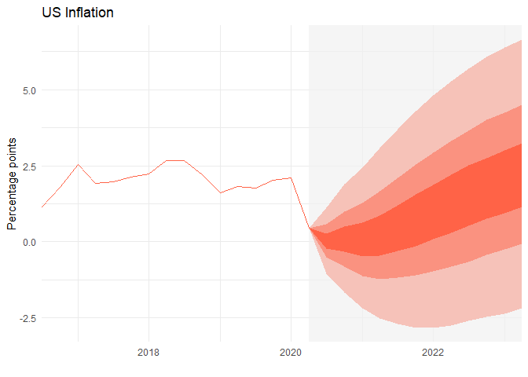

```r
ggi <- ggplot(pg) +
  geom_rect(aes(xmin=min(Date), xmax=max(Date), ymin=-Inf, ymax=Inf), fill=col[1], alpha=.15) +
  geom_polygon(aes(x=Date, y=coord, group=Area, fill=Area)) +
  geom_line(data=bd,aes(x=Date, y=Data), col=centre[j]) +
  scale_fill_manual(values=col[2:6]) +
  labs(title="US Inflation", y="Percentage points", x="") +
  scale_x_date(expand = c(0,0)) +
  theme_minimal() +
  theme(legend.position = "none")
plot(ggi)
```

#### Quantile fan chart; each colour has 30% of the distribution

### HPDI Fan chart

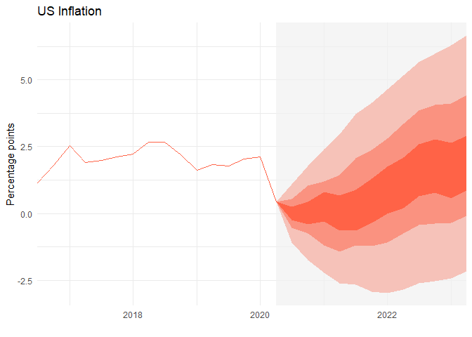

```r
library(HDInterval)
p3 <- hdi(outf, .3)
p6 <- hdi(outf, .6)
p9 <- hdi(outf, .9)

pp <- as_tibble(bind_cols(p9[1,],p6[1,],p3[1,],p3[2,],p6[2,],p9[2,]), .name_repair = "unique") %>%
  add_row(as_tibble(matrix(tail(data$INF,1),1,6), .name_repair = "unique"), .before = 1) %>%
  as.matrix()

ph  <- rbind(pp[,-6], pp[(nf+1):1,-1]) %>%
  as_tibble() %>%
  rename_all( ~ c(paste0("Area",1:5))) %>%
  mutate(Date = c(fdt,rev(fdt))) %>%
  gather(Area, coord, -Date)
ggi <- ggplot(ph) +
  geom_rect(aes(xmin=min(Date), xmax=max(Date), ymin=-Inf, ymax=Inf), fill=col[1], alpha=.15) +
  geom_polygon(aes(x=Date, y=coord, group=Area, fill=Area)) +
  geom_line(data=bd,aes(x=Date, y=Data), col=centre[j]) +
  scale_fill_manual(values=col[2:6]) +
  labs(title="US Inflation", y="Percentage points", x="") +
  scale_x_date(expand = c(0,0)) +
  theme_minimal() +
  theme(legend.position = "none")
plot(ggi)
```

#### HPDI fan chart; each colour has 30% of the distribution